# DATA1901 Project 1

On the Influence of US College Majors

University of Sydney | Semester 1 | March 2019

# 1 Executive Summary

# 2 Full Report

## 2.1 Initial Data Analysis (IDA)

```r
gradData = read.csv("data/recent-grads.csv")
```

### 2.1.1 Source

Data collected from the American Community Survey 2010 - 2012 Public Use Microdata Series (PUMS Data) at the [USA Census Website](https://www.census.gov/programs-surveys/acs/data/pums.html). It was initially wrangled by American media company [FiveThirtyEight](https://github.com/fivethirtyeight/data/tree/master/college-majors). The code used to wrangle the data can be viewed [here](https://github.com/fivethirtyeight/data/blob/master/college-majors/college-majors-rscript.R).

Note that:

- Data was not adjusted for inflation
- “Recent-grads” data was filtered to only include subjects below the age of *28*

### 2.1.2 Data Dictionary

```r
# View the structure of the data:
str(gradData)
```

```
## 'data.frame':    173 obs. of  21 variables:
##  $ Rank                : int  1 2 3 4 5 6 7 8 9 10 ...
##  $ Major_code          : int  2419 2416 2415 2417 2405 2418 6202 5001 2414 2408 ...
##  $ Major               : Factor w/ 173 levels "ACCOUNTING","ACTUARIAL SCIENCE",..: 141 116 113 132 24 134 2 15 109 53 ...
##  $ Total               : int  2339 756 856 1258 32260 2573 3777 1792 91227 81527 ...
##  $ Men                 : int  2057 679 725 1123 21239 2200 2110 832 80320 65511 ...
##  $ Women               : int  282 77 131 135 11021 373 1667 960 10907 16016 ...
##  $ Major_category      : Factor w/ 16 levels "Agriculture & Natural Resources",..: 8 8 8 8 8 8 4 14 8 8 ...
##  $ ShareWomen          : num  0.121 0.102 0.153 0.107 0.342 ...
##  $ Sample_size         : int  36 7 3 16 289 17 51 10 1029 631 ...
##  $ Employed            : int  1976 640 648 758 25694 1857 2912 1526 76442 61928 ...
##  $ Full_time           : int  1849 556 558 1069 23170 2038 2924 1085 71298 55450 ...
##  $ Part_time           : int  270 170 133 150 5180 264 296 553 13101 12695 ...
##  $ Full_time_year_round: int  1207 388 340 692 16697 1449 2482 827 54639 41413 ...
##  $ Unemployed          : int  37 85 16 40 1672 400 308 33 4650 3895 ...
##  $ Unemployment_rate   : num  0.0184 0.1172 0.0241 0.0501 0.0611 ...
##  $ Median              : int  110000 75000 73000 70000 65000 65000 62000 62000 60000 60000 ...
##  $ P25th               : int  95000 55000 50000 43000 50000 50000 53000 31500 48000 45000 ...
##  $ P75th               : int  125000 90000 105000 80000 75000 102000 72000 109000 70000 72000 ...
##  $ College_jobs        : int  1534 350 456 529 18314 1142 1768 972 52844 45829 ...
##  $ Non_college_jobs    : int  364 257 176 102 4440 657 314 500 16384 10874 ...
##  $ Low_wage_jobs       : int  193 50 0 0 972 244 259 220 3253 3170 ...
```

This data consists of 20 variables (excluding “Rank” which orders the subjects by Median income).

#### Major_code

A unique code for each major, given by the [source](https://www.census.gov/programs-surveys/acs/data/pums.html).  
*Type*: Integer  
*Assessment*: Although it is a number, a factor classification would be more suitable as the codes are considered nominal (no order).

#### Major

The major’s name.  
*Type*: Factor  
*Assessment*: Either a character or factor classification would be suitable.

#### Total, Men, Women

Amount of total people, men, and women respectively with that major in the sample for 2010-2012.  
*Type*: Integer  
*Assessment*: Suitable.

#### Major_category

General category for that major (e.g. “Engineering”).  
*Type*: Factir  
*Assessment*: Suitable - allows for easy classification and plotting.

#### ShareWomen

Women as a percentage of Total.  
*Type*: Number  
*Assessment*: Suitable, since it is provided as a decimal (multiply by 100 if plotting percentages).

#### Sample_size

Sample size for calculating income quartiles.  
*Type*: Integer  
*Assessment*: Suitable.

#### Employed, Full_time, Part_time

Number of people employed, employed 35 hours or more per week, and employed 35 hours or less respectively.  
*Type*: Integer  
*Assessment*: Suitable.

#### Full_time_year_round

Number of people employed for at least 50 weeks per year and over 35 hours hours per week.  
*Type*: Integer  
*Assessment*: Suitable.

#### Unemployed

Number of people considered unemployed by census data.  
*Type*: Integer  
*Assessment*: Suitable.

#### Unemployment_rate

The percentage of people unemployed over (unemployed + employed).  
*Type*: Number  
*Assessment*: Suitable.

#### Median, P25th, P75th

Meadian, 25th percentile, and 75th percentile earnings respectively for full-time, year-round workers.  
*Type*: Integer  
*Assessment*: Suitable - although income is continuous, it can be considered discrete without significantly impacting the data.

#### College_jobs, Non_college_jobs, Low_wage_jobs

Number of people with a job requiring a college degree, not requiring a college degree, and in a low-wage service job respectively.  
*Type*: Integer  
*Assessment*: Suitable.

### 2.1.4 Data Wrangling

```r
# Remove rows with blank values
```

## 2.2 New questions:

Q1: Which college majors give the highest incomes? Sub-question: How does this take into account spread (i.e. compare 75th vs median vs 25th)

Q2: Which college majors give the highest employability (based on unemployment)? Sub-question: How much of this employment is actually in their field / based on the degree (looking at college jobs vs non-college jobs)?

Q3: Which college majors pay the most per time worked (looking at % full time)?

Q3 (alternative): Looking at the results from Q1 and Q2, how do these “rankings” align with the popularity of these courses (based on total people = employed + unemployed)

## 2.3 Research Question 1

**Which college major should a student take to receive the highest income?**

There are three variables to consider when looking at income - the 25th percentile, median, and 75th percentile. Additionally, it is important to consider whether to look at individual majors or major categories.  
Taking the Median income against major category initially, we get:

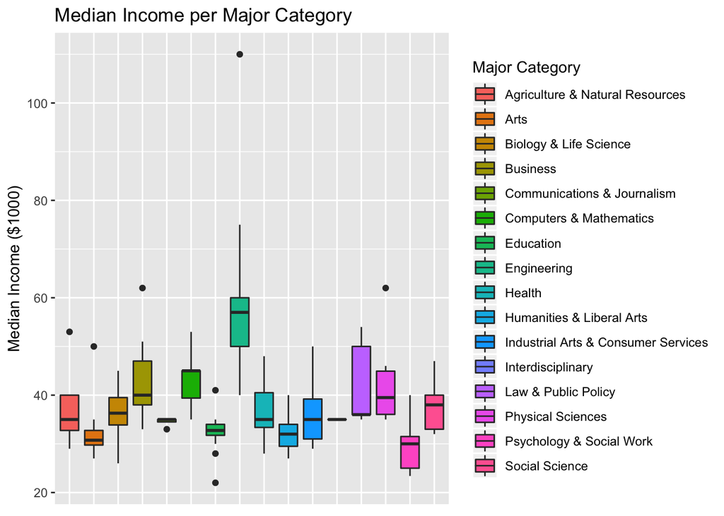

```r
ggplot(gradData, aes(x=factor(Major_category), y=Median/1000)) +
  geom_boxplot(aes(fill = factor(Major_category))) +
  theme(axis.text.x = element_blank(), axis.title.x = element_blank(), axis.ticks.x = element_blank()) +
  labs(fill = "Major Category", title = "Median Income per Major Category") +
  ylab("Median Income ($1000)")
```

Removing the outlier in Engineering:

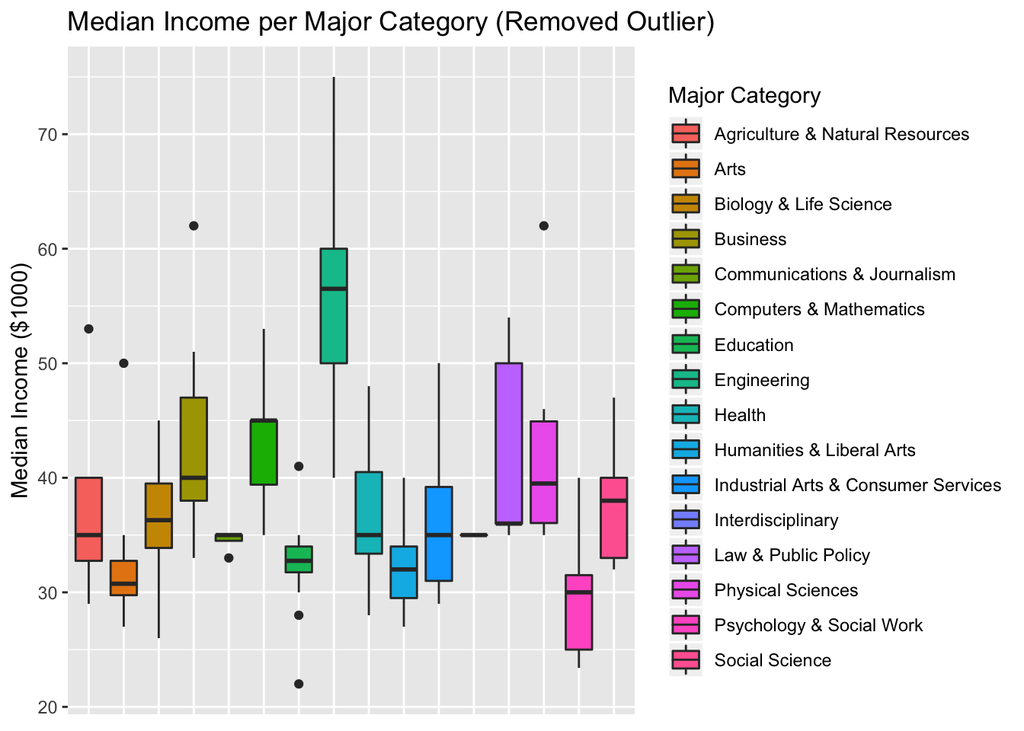

```r
ggplot(gradData[gradData$Median<100000,], aes(x=factor(Major_category), y=Median/1000)) +
  geom_boxplot(aes(fill = factor(Major_category))) +
  theme(axis.text.x = element_blank(), axis.title.x = element_blank(), axis.ticks.x = element_blank()) +
  labs(fill = "Major Category", title = "Median Income per Major Category (Removed Outlier)") +
  ylab("Median Income ($1000)")
```

Looking instead at individual majors, we initially have too many datapoints to make sense of the information. Instead, since the data is already ordered by median income, we can take the top 10 results before graphing:

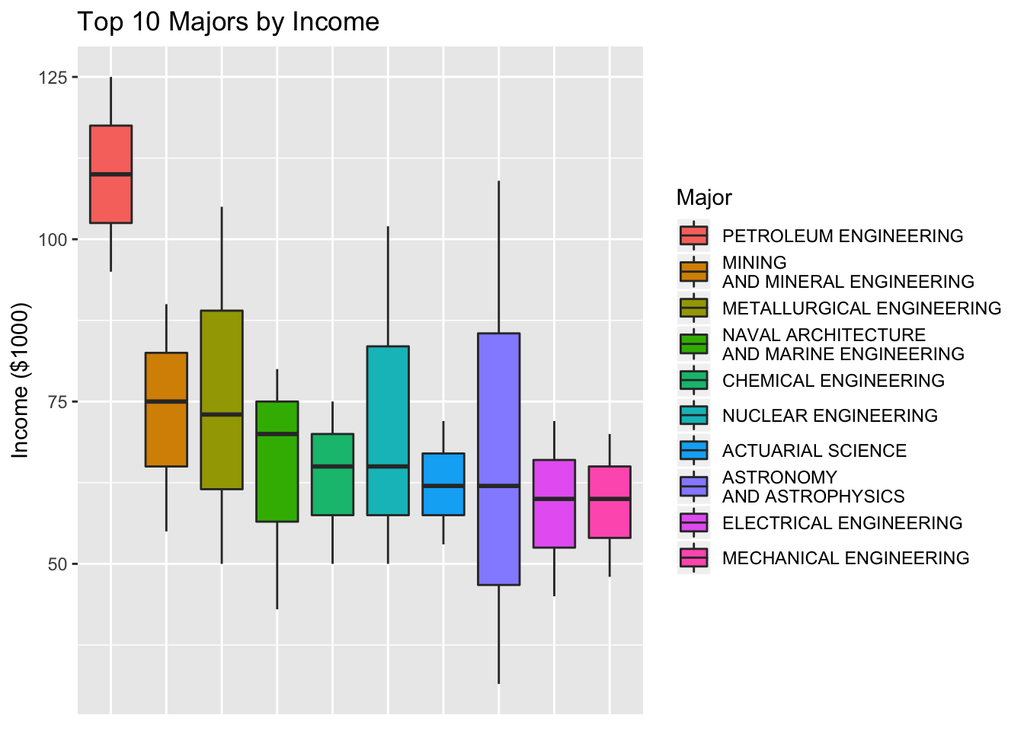

```r
# Selects top 10
gradData.head = head(gradData, n=10)
# Creates a new data frame to be able to plot median, 25th, and 75th percentiles on the same graph
median.df = data.frame(Major = gradData.head$Major, Major_category=gradData.head$Major_category,
                       Income = gradData.head$Median)
p25.df = data.frame(Major = gradData.head$Major, Major_category=gradData.head$Major_category,
                       Income = gradData.head$P25th)
p75.df = data.frame(Major = gradData.head$Major, Major_category=gradData.head$Major_category,
                       Income = gradData.head$P75th)
gradData.head.df = rbind(median.df, p25.df, p75.df)
# For reordering the majors
score = rbind(gradData.head, gradData.head, gradData.head)
# Plots a boxplot
ggplot(gradData.head.df, aes(x=reorder(Major, -score$Median), y=Income/1000)) +
  geom_boxplot(aes(fill = reorder(sub("AND", "\nAND",Major), -score$Median))) +
  theme(axis.text.x = element_blank(), axis.title.x = element_blank(),
        axis.ticks.x = element_blank()) +
  labs(fill = "Major", title = "Top 10 Majors by Income") +
  ylab("Income ($1000)") + xlab("Major")
```

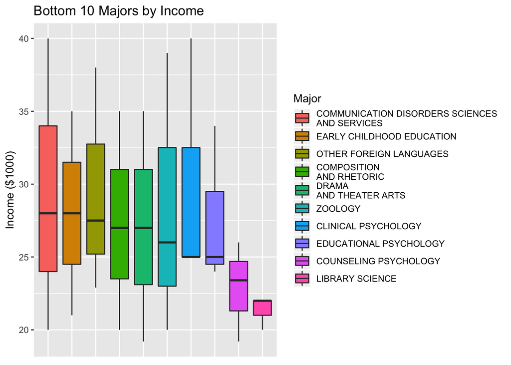

```r
# Selects bottom 10
gradData.tail = tail(gradData, n=10)
# Creates a new data frame to be able to plot median, 25th, and 75th percentiles on the same graph
median.df = data.frame(Major = gradData.tail$Major, Major_category=gradData.tail$Major_category,
                       Income = gradData.tail$Median)
p25.df = data.frame(Major = gradData.tail$Major, Major_category=gradData.tail$Major_category,
                       Income = gradData.tail$P25th)
p75.df = data.frame(Major = gradData.tail$Major, Major_category=gradData.tail$Major_category,
                       Income = gradData.tail$P75th)
gradData.tail.df = rbind(median.df, p25.df, p75.df)
# For reordering the majors
score = rbind(gradData.tail, gradData.tail, gradData.tail)
# Plots a boxplot
ggplot(gradData.tail.df, aes(x=reorder(Major, -score$Median), y=Income/1000)) +
  geom_boxplot(aes(fill = reorder(sub("AND", "\nAND",Major), -score$Median))) +
  theme(axis.text.x = element_blank(), axis.title.x = element_blank(),
        axis.ticks.x = element_blank()) +
  labs(fill = "Major", title = "Bottom 10 Majors by Income") +
  ylab("Income ($1000)") + xlab("Major")
```

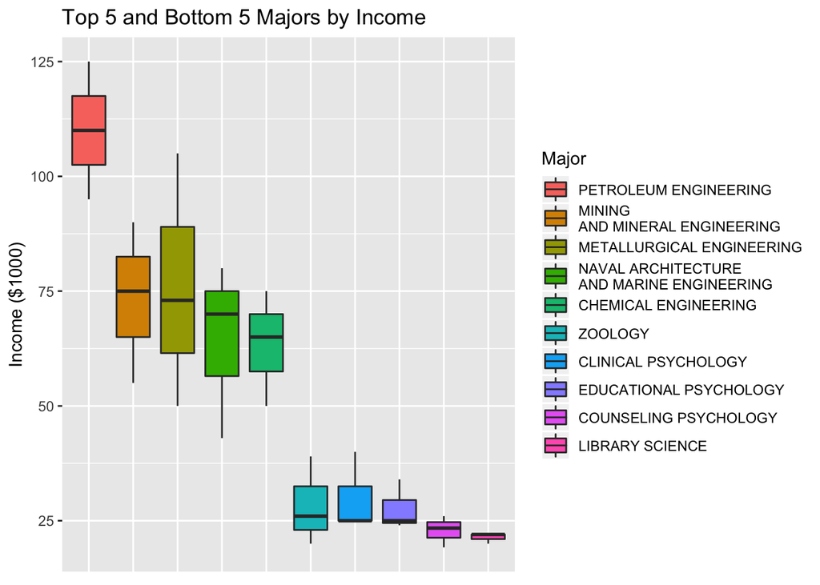

```r
# Selects top 5
gradData.head = head(gradData, n=5)
# Creates a new data frame to be able to plot median, 25th, and 75th percentiles on the same graph
median.df = data.frame(Major = gradData.head$Major, Major_category=gradData.head$Major_category,
                       Income = gradData.head$Median)
p25.df = data.frame(Major = gradData.head$Major, Major_category=gradData.head$Major_category,
                       Income = gradData.head$P25th)
p75.df = data.frame(Major = gradData.head$Major, Major_category=gradData.head$Major_category,
                       Income = gradData.head$P75th)
gradData.head.df = rbind(median.df, p25.df, p75.df)
# Selects bottom 5
gradData.tail = tail(gradData, n=5)
# Creates a new data frame to be able to plot median, 25th, and 75th percentiles on the same graph
median.df = data.frame(Major = gradData.tail$Major, Major_category=gradData.tail$Major_category,
                       Income = gradData.tail$Median)
p25.df = data.frame(Major = gradData.tail$Major, Major_category=gradData.tail$Major_category,
                       Income = gradData.tail$P25th)
p75.df = data.frame(Major = gradData.tail$Major, Major_category=gradData.tail$Major_category,
                       Income = gradData.tail$P75th)
gradData.tail.df = rbind(median.df, p25.df, p75.df)
score = rbind(gradData.tail, gradData.tail, gradData.tail)
# Combines the two
gradData.tail.df =rbind(gradData.head.df, gradData.tail.df)
# Orders it
score = rbind(gradData.head, gradData.head, gradData.head, score)
# Plots a boxplot
ggplot(gradData.tail.df, aes(x=reorder(Major, -score$Median), y=Income/1000)) +
  geom_boxplot(aes(fill = reorder(sub("AND", "\nAND",Major), -score$Median))) +
  theme(axis.text.x = element_blank(), axis.title.x = element_blank(),
        axis.ticks.x = element_blank()) +
  labs(fill = "Major", title = "Top 5 and Bottom 5 Majors by Income") +
  ylab("Income ($1000)") + xlab("Major")
```

## 2.4 Research Question 2

Summary:

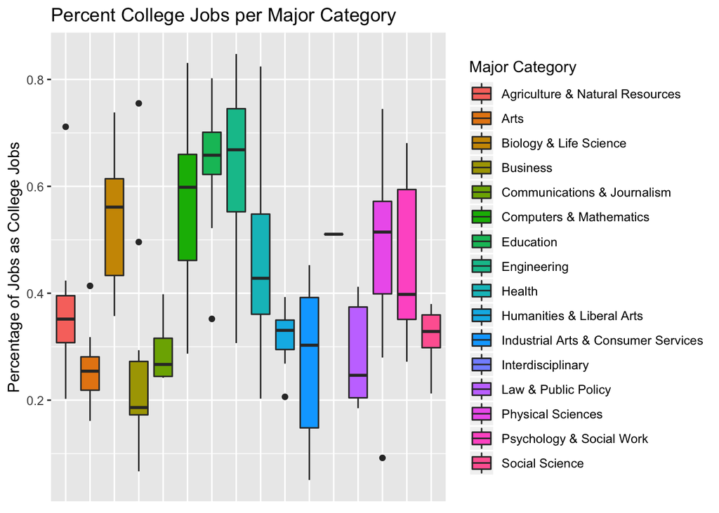

```r
percentCollege = gradData$College_jobs/(gradData$College_jobs+gradData$Non_college_jobs+gradData$Low_wage_jobs)
ggplot(gradData, aes(x=factor(Major_category), y=percentCollege)) +
  geom_boxplot(aes(fill = factor(Major_category))) +
  theme(axis.text.x = element_blank(), axis.title.x = element_blank(), axis.ticks.x = element_blank()) +
  labs(fill = "Major Category", title="Percent College Jobs per Major Category") +
  ylab("Percentage of Jobs as College Jobs")
```

## 2.5 Research Question 3

# 3 Conclusions

# 4 References

Style: APA Major categories were sourced from [“What’s It Worth?: The Economic Value of College Majors.” Georgetown University Center on Education and the Workforce, 2011](http://cew.georgetown.edu/whatsitworth).

# 5 Personal reflection on group work